# Predicting Stock Trends with Machine Learning

**Authors:** Bruce Jiang, Joshua Elubiaozor

# Introduction

From the big screen with movies such as The Wolf on Wall Street to dinner room table conversations, it seems that making it big using the stock market is its own American dream. Heavily fantasized, the reality is "...as much as 90% of people lose their money in stock markets..." (https://www.researchandranking.com/blog/shocking-but-true-90-people-lose-money-in-stocks). However, equipped with technology previously unavailable years ago, would it be possible to use machine learning and complex algorithms at least mitigate the risk, or even accurately predict stock market trends/movements?

For general knowledge, the Adjusted Price of a stock, amends a stock's closing price to reflect that stock's value after accounting for any corporate actions. The adjusted closing price factors in corporate actions, such as stock splits, dividends, and rights offerings. T learn more, you can check out https://www.thebalance.com/what-is-adjusted-closing-price-5190242. It might be helpful to understand that little piece of information because the algorithms is developed on Adjusted Closing prices.

# Data

## Gathering Processing

Yahoo! Finance provides a straightforward method of obtaining a csv that contains open, high, low, close, adjusted close, and volume for any given date from IPO.

### How to obtain CSV

1. Go to https://finance.yahoo.com/
2. In the search bar, enter desired stock's symbol/ticker
3. Select the historical data tab
4. Click on download **Note: Choose any time period you desire, for this tutorial we'll be working with IPO**

**Visual Provided Below:**

[figure not shown]

## Load/View Data

Data on stock exchanges is very well managed, and thus very little wrangling is needed in this context. Therefore, to view the data, we just read the csv file with pandas.

```python
import pandas as pd
import numpy as np
import seaborn as sns
import matplotlib.pyplot as plt
import pandas_datareader as reader
import datetime as datetime
from sklearn.preprocessing import MinMaxScaler
from tensorflow.keras.models import Sequential
from keras import Sequential
from keras.layers import LSTM
from keras.layers import Dense, Dropout
from keras.utils.vis_utils import plot_model
from sklearn.model_selection import train_test_split
qqq_data = pd.read_csv("QQQ.csv", index_col = "Date", parse_dates = True) #Read csv with pandas, parse dates and set date as index column
qqq_data.head()
```

| Date | Open | High | Low | Close | Adj Close | Volume |
| --- | --- | --- | --- | --- | --- | --- |
| 1999-03-10 | 51.12500 | 51.156250 | 50.28125 | 51.0625 | 44.286324 | 5232000 |
| 1999-03-11 | 51.43750 | 51.734375 | 50.31250 | 51.3125 | 44.503139 | 9688600 |
| 1999-03-12 | 51.12500 | 51.156250 | 49.65625 | 50.0625 | 43.419033 | 8743600 |
| 1999-03-15 | 50.43750 | 51.562500 | 49.90625 | 51.5000 | 44.665775 | 6369000 |
| 1999-03-16 | 51.71875 | 52.156250 | 51.15625 | 51.9375 | 45.045200 | 4905800 |

Now, we need to check for null values:

```python
print(f"Null Values: {qqq_data.isnull().sum().sum()}")
```

```
Null Values: 0
```

Yahoo!(Pun intended) Yahoo catalogues their data very well and thus there are no null variables. We can now move on without worry.

For a more detailed visual, we can view our data as a graph:

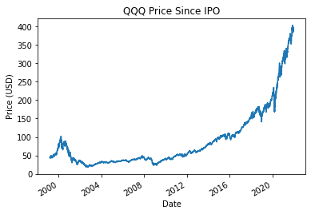

```python
qqq_data["Adj Close"].plot(xlabel = "Date", ylabel = "Price (USD)", title = "QQQ Price Since IPO")
```

# Model

Now that we have our data ready, we can proceed to move on to creating a model that will predict stock movements. We'll be using an LTSM Network, or Long Short-Term Memory Network. We'll be using LTSM for a few reasons. LTSM Networks are capable of making predictions over time, as well as being relatively insensitive to gaps in time.

Further information on LTSM can be found here: https://colah.github.io/posts/2015-08-Understanding-LSTMs/

Before we can insert our data into our model, we should split our data into training and test data. We're going to use a test size of 15%, but for higher accuracy you can always decrease the parameter.

```python
x_train, x_test, y_train, y_test = train_test_split(qqq_data[["Open","High","Low","Volume"]], qqq_data["Adj Close"], test_size=0.15, random_state=42)
```

We've now split our data into training and testing, using Open, High, Low, and Volume as our input data and using Adjusted Close as our output. Here, we can quickly look at how our data looks.

```python
print(x_train)
print(x_test)
```

```
                  Open        High         Low    Volume
Date
2016-10-20  117.730003  117.970001  117.029999  18132200
2012-03-06   63.570000   63.720001   63.230000  54638600
2000-08-02   87.875000   90.390625   86.500000  23578200
2012-12-19   66.739998   66.760002   66.220001  34832500
2005-08-17   38.919998   39.169998   38.790001  74470500
...                ...         ...         ...       ...
2014-03-07   91.269997   91.360001   90.070000  31167800
2019-10-24  193.589996  194.210007  192.740005  18998500
2019-12-13  206.399994  207.910004  205.960007  32519400
2020-08-10  271.769989  271.980011  266.670013  35088400
2002-08-12   23.049999   23.480000   22.900000  62870900

[4873 rows x 4 columns]
                  Open        High         Low     Volume
Date
2020-11-24  291.489990  294.980011  289.630005   24516800
2011-09-27   55.709999   56.200001   54.980000   81148600
2012-10-01   68.900002   69.330002   68.250000   37715300
2010-09-24   49.220001   49.689999   49.150002   79495900
2009-10-08   42.310001   42.619999   42.139999  107850400
...                ...         ...         ...        ...
2006-08-28   38.290001   38.790001   38.240002   80035000
2015-06-05  109.430000  109.690002  108.629997   22641700
1999-10-04   60.531250   61.781250   60.187500   12434200
2014-08-06   94.000000   95.110001   93.919998   34431900
2010-11-15   52.779999   52.880001   52.290001   56723400

[860 rows x 4 columns]
```

```python
print(y_train)
print(y_test)
```

```
Date
2016-10-20    113.337433
2012-03-06     57.791950
2000-08-02     75.183723
2012-12-19     60.650864
2005-08-17     34.228508
                 ...
2014-03-07     84.653397
2019-10-24    191.895203
2019-12-13    204.847076
2020-08-10    268.870239
2002-08-12     20.294731
Name: Adj Close, Length: 4873, dtype: float64
Date
2020-11-24    292.901581
2011-09-27     50.127239
2012-10-01     62.673767
2010-09-24     44.638851
2009-10-08     37.631493
                 ...
2006-08-28     33.979816
2015-06-05    103.579659
1999-10-04     53.392933
2014-08-06     88.824562
2010-11-15     47.020905
Name: Adj Close, Length: 860, dtype: float64
```

Our data seems to be in order, which means we can now move onto building our model.

```python
#Model Architecture
lstm = Sequential()
lstm.add(LSTM(32, input_shape=(1, x_train.shape[1]), activation="relu", return_sequences=False))
lstm.add(Dense(1))
#An optimizer is used to help improve upon the Loss function, while the Loss function gives us information on
#how the model did on training.
lstm.compile(loss="mean_squared_error", optimizer="adam")
```

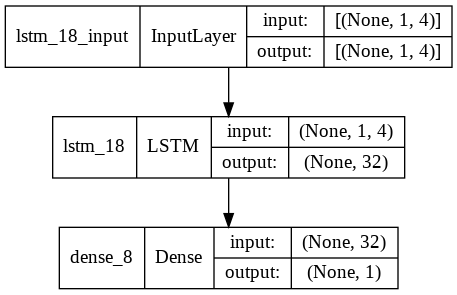

```python
plot_model(lstm, show_shapes=True, show_layer_names=True)
```

```python
xtrain = np.array(x_train)
xtrain = xtrain.reshape(xtrain.shape[0], 1, xtrain.shape[1]) #Reshape data to align with parameter
#Here we start training the model by setting it to iterate over the entire dataset a 100 times, with a batch size of 8
history = lstm.fit(xtrain, y_train, epochs = 100, batch_size = 8, verbose = 1, shuffle = False)
```

```python
#Convert to a np array so that we can use it in our LSTM Model.
xtest = np.array(x_test)
#Now we need to reshape our data because our dataset is 2D but the LSTM Model expects a 3D shape
xtest = xtest.reshape(xtest.shape[0], 1, xtest.shape[1]) #Reshape data to align with parameter
#Next we need to get the models predicted price values
model_pred = lstm.predict(xtest)
model_pred;
```

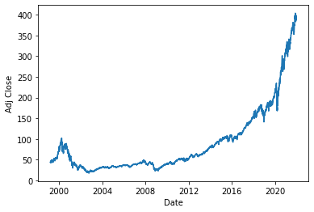

```python
#Actual Stock Prices
sns.lineplot(data=qqq_data, x="Date", y="Adj Close")
```

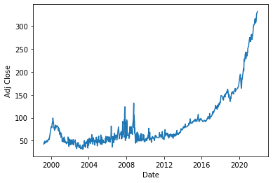

```python
#Predicted Stock Prices
x_test["Adj Close"] = model_pred
sns.lineplot(data=x_test, x="Date", y="Adj Close")
```

**OBSERVATION**

After analysis, we have noticed that although the LSTM model follows the general trends of the graph, it sometimes over/underestimates the prices greatly.

**GOAL**

Our goal was to analyze stock history with two different types of models. In this next part we will be using more layers of an LSTM model than our previous solution. This model will have an additional Dropout layer to further help to prevent overfitting. On our first model, we noticed that our model ws overfitting the data that we had even after training the model multiple times. Using a different and more extensive use of data. We will create and load a new stock by the ticker symbol RIOT for the company RIOT.

```python
#First we load in the data
riot_data = pd.read_csv("RIOT2016to2019.csv", index_col = "Date", parse_dates = True) #Read csv with pandas, parse dates and set date as index column
riot_data.head()

#Next we prepare the data
scale = MinMaxScaler(feature_range = (0, 1))
#Next we reshape the data to be able to fit the liner regression model
reshaped_data = riot_data['Close'].values.reshape(-1, 1)
scaling_data = scale.fit_transform(reshaped_data)
scaling_data;
```

```python
#Create empty arrays to store data to train
xtrain = []
ytrain = []
length_of_scale = len(scaling_data)
#We want to start prediction from 50 days to the end of the length of the scaled dataset
#We are going to fill the data by starting at the 50th index and iterate until the end of the scaled data
for values in range(50, length_of_scale):
  #Append values to the train dataset array, we are trying to set the model to train the first 50 values and append that to xtrain
  #Then from the 51st value that we already know we are going to set that to ytrain so that our model will be ble to predict the next values
  xtrain.append(scaling_data[values - 50 : values, 0])
  ytrain.append(scaling_data[values, 0])
```

```python
#Next we start convert the data to an array
xtrain = np.array(xtrain)
#Now we need to reshape our data because our dataset is 2D but the LSTM Model expects a 3D shape just like our previous model
xtrain = np.reshape(xtrain, (xtrain.shape[0], xtrain.shape[1], 1))
ytrain = np.array(ytrain) #Converting the data to an array
#To start building the Model, we will need to couple of things.
#We will need to build layers. We are going to create about 7 layers for our model
second_model = Sequential()
second_model.add(LSTM(40, input_shape = (xtrain.shape[1], 1), return_sequences = True))
#The Dropout layer is used to randomly sets input units to 0 with a frequency of rate
#at each step during training time. I am adding this so as to helps prevent overfitting.
second_model.add(Dropout(0.4))
#Adding another lader to the model to aid in prediction
second_model.add(LSTM(40, return_sequences = True))
#The Dropout layer is used to randomly sets input units to 0 with a frequency of rate
#at each step during training time. I am adding this so as to helps prevent overfitting.
second_model.add(Dropout(0.4))
second_model.add(LSTM(40))
second_model.add(Dropout(0.4))
#This will serve as the neuron that will predict the closing price value from our data after training
second_model.add(Dense(1))
#An optimizer is used to help imporove upon the Loss function, while the Loss function gives us information on
#how the model did on training.
second_model.compile(loss="mean_squared_error", optimizer="adam")
second_model.fit(xtrain, ytrain, epochs = 30, batch_size = 25)
```

```
<keras.callbacks.History at 0x7f57864c9b10>
```

Based on all the data history we have collected, we are now going to find out how well this model performs compared to the previous model.

```python
#Get test data
test = pd.read_csv("RIOT2019to2021.csv", index_col = "Date", parse_dates = True) #Read csv with pandas, parse dates and set date as index column
test.head() #print out
right_stock_price = test['Close'].values
#all_data = pd.read_csv("QQQ", index_col = "Date", parse_dates = True) #Read csv with pandas, parse dates and set date as index column
all_data = pd.concat((riot_data['Close'], test['Close']))
all_data.head() #print out
all_data_length = len(all_data) #get the length so we know where to start
test_length = len(test) #get the length so we know where to start and end
data_sum = all_data_length - test_length #we know the exact length excess of both data
prediction_model = all_data[data_sum - 50 : ].values #we want to go from 1259 - 505 - the number of days to predict which is 50

#Next we need to scale it like before and all we are doing here is repeating the process above
prediction_model = prediction_model.reshape(-1, 1) #We need to reshape this model to column without changing its data

prediction_model_length = len(prediction_model)
prediction_model = scale.transform(prediction_model) #We need to transform because initially we scaled it up before. So now we have to turn it back to data we can use
#create new testing variable array
new_tester = []
#Now we can make predictions with all the data we have, which is what we did earlier, we are just repeating the step
for values in range(50, prediction_model_length):
  #Populate the array
  new_tester.append(prediction_model[values - 50 : values, 0])
```

```python
#After populating the array, next we
new_tester = np.array(new_tester)
#Have to reshape new tester to fit the size of a 3D shape
new_tester = np.reshape(new_tester, (new_tester.shape[0], new_tester.shape[1], 1))

#After gathering all the info now we can predict the stock prices
potential_prices = second_model.predict(new_tester)
#potential_prices = scaler.inverse_transform(potential_prices)
revert_prices = scale.inverse_transform(potential_prices)
revert_prices;
```

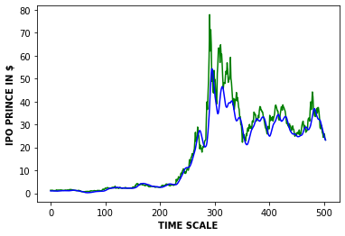

```python
#Plot predictions
plt.plot(right_stock_price, color = 'green')
plt.plot(revert_prices, color = 'blue')
plt.xlabel("TIME SCALE", fontweight = "bold")
plt.ylabel("IPO PRINCE IN $", fontweight = "bold")
```

**LSTM COMPARISON**

**THEOREM**

**CONCLUSION**

In conclusion, with the use of machine learning, we have successfuly analyzed and predicted the price of a stock across specific times. This market prediction was derived with the analysis of Opening Value, Market High per day, Market Low per day and Closing price per day. We also took into consideration the trading volume per day. With all these parameters factored in, we could get a pretty good esimation to what the actual stock prices were using all the above fearture parameters. Although this model yielded a pretty close estimation, the stock prices are steadily affected by the news about the company, activities going on in the country, the economy, news on mergers and collaborations, as well as news on pandemics. These factors can not be predicted ahead of time because of the nature of situations. Through Machine Learning algorithms, technology is able to saves us time and money in the sense that we can spend less time using procedures to compute and analyze market structures, as well as saving us money by creating models to predict the trends of markets which in turn will signify when it is a good time to enter a trade, or signify when to short a stock. Machine learning outperforms humans when it comes to performance and speed. All this is made possible with the analysis of historical data.

```python
from google.colab import drive
drive.mount('/content/drive')
```

```python
! pwd
```

```python
%%shell
jupyter nbconvert --to html ///content/320Final.ipynb
```